# Project A

Bryan Terlizzi

1/31/2021

### Analysis of Gun Deaths in 2012

*Description*  
This is an analysis of the gun deaths police officers in 2012. Variables included in the analysis were the intent, sex, age, race, and educational level.

*Analysis*

There were 1402 documented gun-related police deaths in 2012. The gun deaths of police officers made up approximately 1.4% of all gun-related deaths in the United States. The mean age of the deceased police officers was 36 years old (SD = 13).

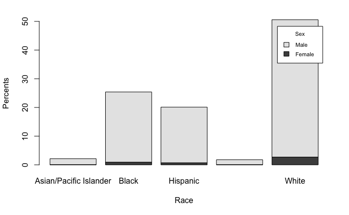

Unsurprisingly, the largest proportion of police deaths were white (51%). Alternatively, the combined proportion of gun-related deaths police officers who were Native Americans/ Native Alaskans or Asian/ Pacific islander was just below 4%. Black and Hispanic officers composed the remaining 25 and 20%, respectively. The proportion of female police officer deaths by gun was around 4.5%, remaining extremely low across all races. In fact, it made up less than 5% of deaths among each different race, with the exception of white police deaths (5.35%). The rest of the sex and race proportion information can be found in Table 1.

*Table 1. Percentages of police deaths by race and gender

```
    Asian/Pacific Islander       Black    Hispanic
  F             0.07132668  0.92724679  0.71326676
  M             2.06847361 24.46504993 19.40085592

    Native American/Native Alaskan       White
  F                     0.07132668  2.71041369
  M                     1.71184023 47.86019971
```

[output not shown]

```r
deaths19 <- all_guns

deaths19$police <- factor(deaths19$police,
                        labels = c("Civilian", "Police Officer"))

police19 <- subset(deaths19, deaths19$police == "Police Officer")

police19_counts <- table(deaths19$police)
police19_props <- prop.table(police19_counts)
police19_props
```

```
      Civilian Police Officer
    0.98690407     0.01309593
```

```r
table(police19$intent)
```

```
Homicide
     520
```

```r
table(police19$sex)
```

```
  F   M
 24 496
```

```r
mean(police19$age)
```

```
[1] 37.92115
```

```r
table(police19$race)
```

```
        Asian/Pacific Islander                          Black
                            21                            117
                      Hispanic Native American/Native Alaskan
                           117                             20
                         White
                           245
```

```r
table(police19$place)
```

```
                   Home Residential institution       School/instiution
                      8                       0                       0
                 Sports                  Street      Trade/service area
                      0                       8                       2
Industrial/construction                    Farm         Other specified
                      0                       0                       1
      Other unspecified
                      2
```

```r
# Calculating mean age of the police officers
mean_age19 <- mean(police19$age)
mean_age19
```

```
[1] 37.92115
```

```r
sd(police19$age)
```

```
[1] 12.87271
```

```r
# Calculating race and sex proportions
sex_counts19 <- table(police19$sex)
sex_props19 <- prop.table(sex_counts19)

race_counts19 <- table(police19$race)
race_props19 <- prop.table(race_counts19)

sex_race_counts19 <- table(police19$sex, police19$race)
sex_race_percents19 <- 100*prop.table(sex_race_counts19)

sex_race_percents19
```

```
    Asian/Pacific Islander      Black   Hispanic
  F              0.0000000  0.5769231  1.5384615
  M              4.0384615 21.9230769 20.9615385

    Native American/Native Alaskan      White
  F                      0.0000000  2.5000000
  M                      3.8461538 44.6153846
```

[figure not shown]

```r
barplot(sex_race_percents19,
        xlab = "Race",
        ylab = "Percents",
        legend = c("Female", "Male"),
        args.legend = list(title = "Sex", cex = .7))
```

```r
race_props19
```

```
        Asian/Pacific Islander                          Black
                    0.04038462                     0.22500000
                      Hispanic Native American/Native Alaskan
                    0.22500000                     0.03846154
                         White
                    0.47115385
```

```r
sex_props19
```

```
         F          M
0.04615385 0.95384615
```